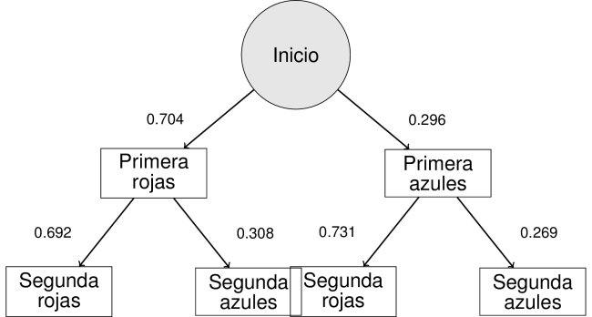

# Question

Una urna contiene 27 bolas: 19 bolas rojas y 8 bolas azules. Se realizan dos extracciones **sin reemplazo**.

El diagrama de árbol mostrado representa todas las posibles combinaciones de extracciones y sus probabilidades asociadas.

Según el diagrama de árbol, ¿cuál es la probabilidad de que en la segunda extracción se obtenga una bola rojas, **dado que** en la primera extracción se obtuvo una bola rojas?

## Answerlist

- 0.4872
- 0.6923
- 0.7037
- 0.7308

# Solution

Para resolver este problema de **probabilidad condicional**, necesitamos aplicar correctamente la definición de probabilidad condicional y analizar el diagrama de árbol.

### Paso 1: Identificar el tipo de problema

Este es un problema de **probabilidad condicional** donde buscamos:

$$P(\text{Segunda extracción = rojas} |
\text{Primera extracción = rojas})$$

### Paso 2: Aplicar la definición de probabilidad condicional

La probabilidad condicional se define como:

$$P(A|B) = \frac{P(A \cap
B)}{P(B)}$$

En nuestro caso:

- **A** = Segunda extracción es rojas
- **B** = Primera extracción es rojas
- **P(A ∩ B)** = Probabilidad de que ambas extracciones sean rojas
- **P(B)** = Probabilidad de que la primera extracción sea rojas

### Paso 3: Calcular probabilidades necesarias

**Probabilidad de la primera extracción (P(B)):**

Como hay 19 bolas rojas de un total de 27 bolas:

$$P(\text{Primera = rojas}) =
\frac{19}{27} = 0.7037$$

**Probabilidad condicional (P(A|B)):**

Si en la primera extracción se obtuvo una bola rojas, quedan:

- 18 bolas rojas
- 8 bolas azules
- Total: 26 bolas

Por lo tanto:

$$P(\text{Segunda = rojas} | \text{Primera
= rojas}) = \frac{18}{26} = 0.6923$$

### Paso 4: Verificación con el diagrama de árbol

En el diagrama de árbol, podemos observar que:

- Del nodo “Primera: rojas” salen dos ramas
- La rama hacia “Segunda: rojas” tiene probabilidad 0.692
- Esta probabilidad coincide con nuestro cálculo: 0.6923

### Paso 5: Análisis de distractores

**Respuesta correcta:** 0.6923

## Answerlist

# Meta-information

exname: Probabilidad Condicional Diagrama Árbol extype: schoice exsolution: 0100 exshuffle: TRUE exsection: Probabilidad Condicional